# StatDescript

StatDescript Yuxuan Li 9/2/2019

```r
summary(bnb.data)
```

```
##        X           log_price         property_type
##  Min.   :    1   Min.   :1.609   Apartment  :23550
##  1st Qu.:18605   1st Qu.:4.317   House      : 8007
##  Median :37025   Median :4.727   Condominium: 1293
##  Mean   :37083   Mean   :4.784   Townhouse  :  815
##  3rd Qu.:55718   3rd Qu.:5.220   Loft       :  611
##  Max.   :74111   Max.   :7.600   Other      :  286
##                                  (Other)    : 1181
##            room_type      amenities          accommodates
##  Entire home/apt:19890   Length:35743       Min.   : 1.000
##  Private room   :14797   Class :character   1st Qu.: 2.000
##  Shared room    : 1056   Mode  :character   Median : 2.000
##                                             Mean   : 3.161
##                                             3rd Qu.: 4.000
##                                             Max.   :16.000
##
##    bathrooms              bed_type          cancellation_policy
##  Min.   :0.000   Airbed       :  244   flexible       :10888
##  1st Qu.:1.000   Couch        :  134   moderate       : 9168
##  Median :1.000   Futon        :  387   strict         :15636
##  Mean   :1.241   Pull-out Sofa:  263   super_strict_30:   43
##  3rd Qu.:1.000   Real Bed     :34715   super_strict_60:    8
##  Max.   :8.000
##
##  cleaning_fee         city       host_has_profile_pic
##  Mode :logical   Boston : 1682   Min.   :0.000
##  FALSE:9566      Chicago: 1800   1st Qu.:1.000
##  TRUE :26177     DC     : 2777   Median :1.000
##                  LA     :10913   Mean   :0.997
##                  NYC    :15458   3rd Qu.:1.000
##                  SF     : 3113   Max.   :1.000
##
##  host_identity_verified host_response_rate   host_since
##  Min.   :0.000          Min.   :0.0000     Min.   :2008-03-04
##  1st Qu.:0.000          1st Qu.:0.9429     1st Qu.:2013-05-01
##  Median :1.000          Median :1.0000     Median :2014-10-03
##  Mean   :0.671          Mean   :0.9430     Mean   :2014-07-25
##  3rd Qu.:1.000          3rd Qu.:1.0000     3rd Qu.:2015-12-23
##  Max.   :1.000          Max.   :1.0000     Max.   :2017-10-04
##
```

[output cut: 57 more lines]

```
##  Min.   :0.0000   Min.   :0.0000   Min.   :0.0000   Min.   :0.0000
##  1st Qu.:0.0000   1st Qu.:1.0000   1st Qu.:1.0000   1st Qu.:0.0000
##  Median :1.0000   Median :1.0000   Median :1.0000   Median :0.0000
##  Mean   :0.5565   Mean   :0.9705   Mean   :0.9712   Mean   :0.4389
##  3rd Qu.:1.0000   3rd Qu.:1.0000   3rd Qu.:1.0000   3rd Qu.:1.0000
##  Max.   :1.0000   Max.   :1.0000   Max.   :1.0000   Max.   :1.0000
##
##  cleanning_fee
##  Min.   :0.0000
##  1st Qu.:0.0000
##  Median :1.0000
##  Mean   :0.7324
##  3rd Qu.:1.0000
##  Max.   :1.0000
##
```

```r
bnb.data <- mutate(bnb.data,price = exp(log_price))

quant.data <- bnb.data %>%
  select(log_price, accommodates, beds, bedrooms, bathrooms, number_of_amenities,
         review_scores_rating, number_of_reviews, host_response_rate, post_wait)

#pairs(quant.data)
summary(quant.data)
```

```
##    log_price      accommodates         beds           bedrooms
##  Min.   :1.609   Min.   : 1.000   Min.   : 0.000   Min.   : 0.000
##  1st Qu.:4.317   1st Qu.: 2.000   1st Qu.: 1.000   1st Qu.: 1.000
##  Median :4.727   Median : 2.000   Median : 1.000   Median : 1.000
##  Mean   :4.784   Mean   : 3.161   Mean   : 1.716   Mean   : 1.271
##  3rd Qu.:5.220   3rd Qu.: 4.000   3rd Qu.: 2.000   3rd Qu.: 1.000
##  Max.   :7.600   Max.   :16.000   Max.   :16.000   Max.   :10.000
##    bathrooms     number_of_amenities review_scores_rating
##  Min.   :0.000   Min.   : 1.00       Min.   : 20.00
##  1st Qu.:1.000   1st Qu.:13.00       1st Qu.: 93.00
##  Median :1.000   Median :17.00       Median : 94.10
##  Mean   :1.241   Mean   :17.66       Mean   : 94.11
##  3rd Qu.:1.000   3rd Qu.:22.00       3rd Qu.: 99.00
##  Max.   :8.000   Max.   :77.00       Max.   :100.00
##  number_of_reviews host_response_rate   post_wait
##  Min.   :  0.00    Min.   :0.0000     Min.   :-931.0
##  1st Qu.:  1.00    1st Qu.:0.9429     1st Qu.: 143.5
##  Median :  6.00    Median :1.0000     Median : 671.0
##  Mean   : 20.72    Mean   :0.9430     Mean   :1143.5
##  3rd Qu.: 23.00    3rd Qu.:1.0000     3rd Qu.:1772.0
##  Max.   :532.00    Max.   :1.0000     Max.   :3204.0
```

# 1.Number of amenity

First of first, take a look of numeric characters on price, including the numbers of **accomodates, beds, bedrooms, and bathrooms**. Do scatter plot and violin plot of (log-)price on each varaiable.

### Conclusion:

- The log price and those numbers have roughly positive relationship (sort of sigmoid). I think quadratic term might be necessary in linear regression.
- Further controls are needed.

```r
amen.data <- bnb.data %>%
  select(price, log_price, accommodates, beds, bedrooms, bathrooms,
         has_review, number_of_reviews) %>%
  na.omit() # 35835 obs

summary(amen.data)
```

```
##      price          log_price      accommodates         beds
##  Min.   :   5.0   Min.   :1.609   Min.   : 1.000   Min.   : 0.000
##  1st Qu.:  75.0   1st Qu.:4.317   1st Qu.: 2.000   1st Qu.: 1.000
##  Median : 113.0   Median :4.727   Median : 2.000   Median : 1.000
##  Mean   : 161.3   Mean   :4.784   Mean   : 3.161   Mean   : 1.716
##  3rd Qu.: 185.0   3rd Qu.:5.220   3rd Qu.: 4.000   3rd Qu.: 2.000
##  Max.   :1999.0   Max.   :7.600   Max.   :16.000   Max.   :16.000
##     bedrooms        bathrooms     has_review number_of_reviews
##  Min.   : 0.000   Min.   :0.000   0: 7634    Min.   :  0.00
##  1st Qu.: 1.000   1st Qu.:1.000   1:28109    1st Qu.:  1.00
##  Median : 1.000   Median :1.000              Median :  6.00
##  Mean   : 1.271   Mean   :1.241              Mean   : 20.72
##  3rd Qu.: 1.000   3rd Qu.:1.000              3rd Qu.: 23.00
##  Max.   :10.000   Max.   :8.000              Max.   :532.00
```

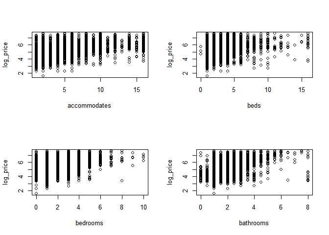

```r
# log price to ammenity numbers
par(mfrow = c(2, 2))
for (i in 3:6){
  plot(amen.data[,2] ~ amen.data[,i],
        xlab = colnames(amen.data)[i], ylab = colnames(amen.data)[2])
}
```

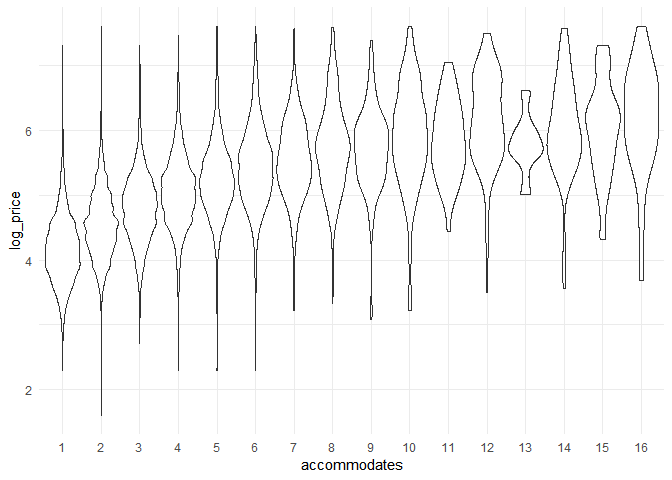

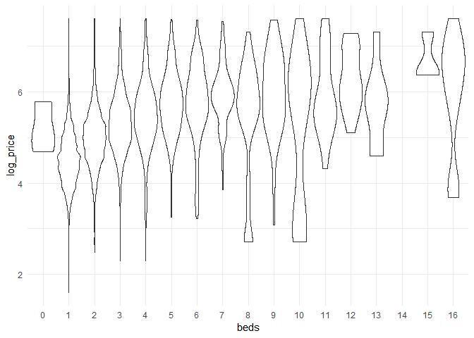

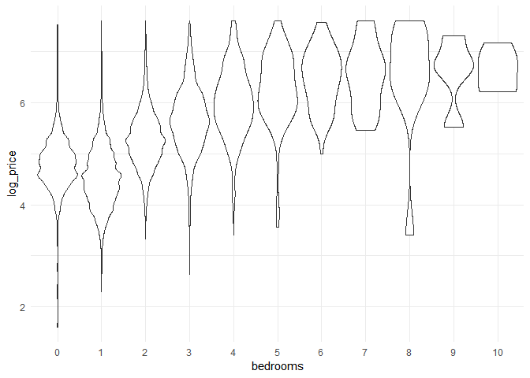

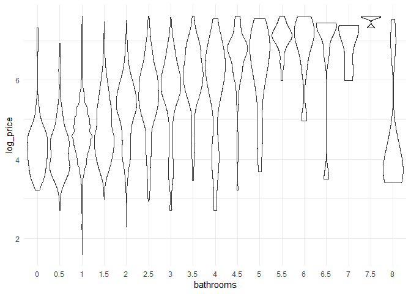

```r
# better(?) version
for (i in 3:6){
  p <- ggplot(amen.data,
              aes(x = as.factor(amen.data[,i]), y = amen.data[,2]),
                  fill = has_review) +
    geom_violin(scale = "width") +
    xlab(colnames(amen.data)[i]) +
    ylab(colnames(amen.data)[2]) +
    theme_minimal()

  print(p)
}
```

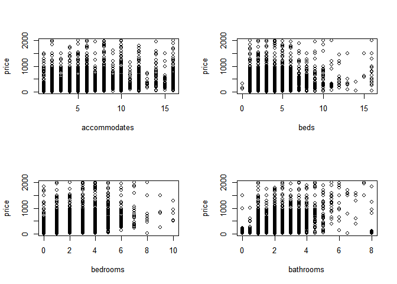

```r
# price to ammenity numbers
par(mfrow = c(2, 2))
for (i in 3:6){
plot(amen.data[,1] ~ amen.data[,i],
xlab = colnames(amen.data)[i], ylab = colnames(amen.data)[1])
}
```

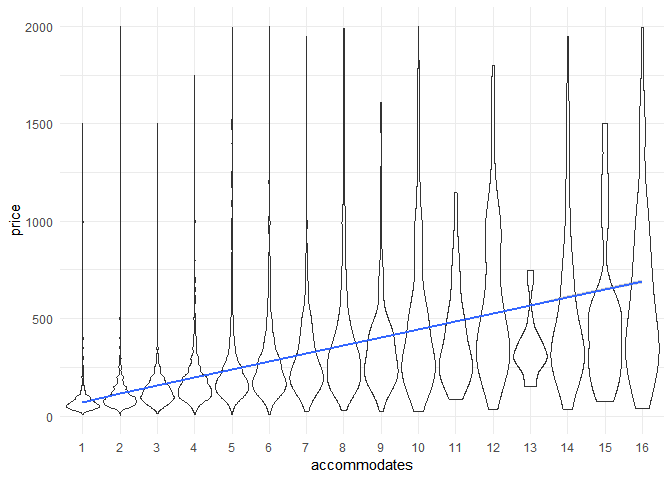

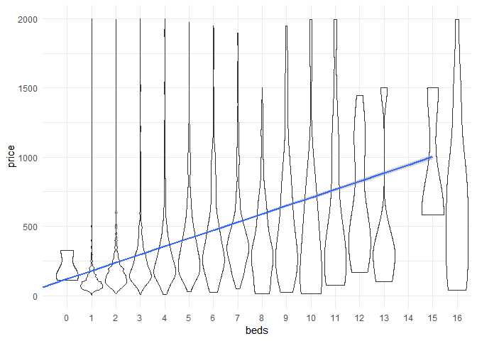

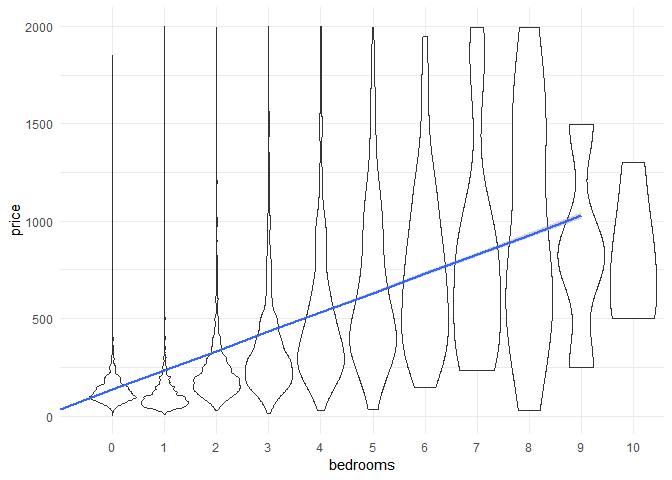

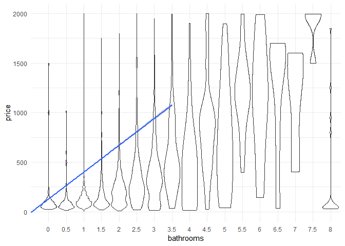

```r
# better(?) version
for (i in 3:6){
  p <- ggplot(amen.data,aes(x = as.factor(amen.data[,i]), y = amen.data[,1])) +
    geom_violin(scale = "width") +
    geom_smooth(aes(x = amen.data[,i], y = amen.data[,1]),method = "lm") +
    xlab(colnames(amen.data)[i]) +
    ylab(colnames(amen.data)[1]) +
    theme_minimal()

  print(p)
}
```

# 2. Hosts and Reviews

Now consider numerical variables **host_response_rate, number_of_reviews, review_scores_rating**, and logical variables **host_has_profile_pic** and **host_identity_verified**.

Note: if No first_review -> number_of_reviews = 0 -> review_scores_rating is NA. -> No host_response_rate (roughly)

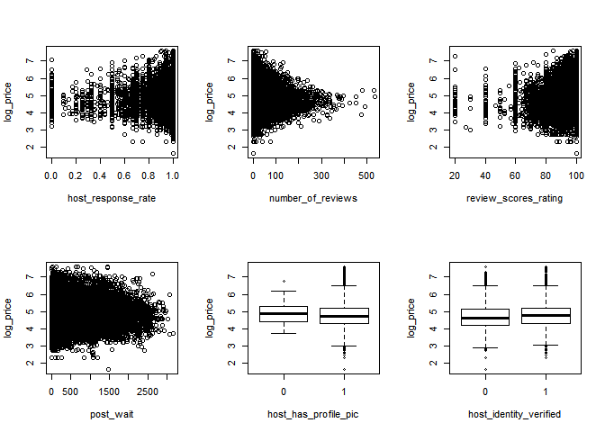

```r
hore.data <- bnb.data %>%
  select(price, log_price,
         host_response_rate, number_of_reviews, review_scores_rating,
         post_wait, host_has_profile_pic, host_identity_verified) %>%
  mutate(host_has_profile_pic = as.factor(host_has_profile_pic),
         host_identity_verified = as.factor(host_identity_verified)) %>%
  filter(post_wait >0 & post_wait < max(post_wait))
# summary(hore.data)


# log price to host and reviews
par(mfrow = c(2, 3))
for (i in 3:8){
  plot(hore.data[,2] ~ hore.data[,i],
        xlab = colnames(hore.data)[i], ylab = colnames(hore.data)[2])
}
```

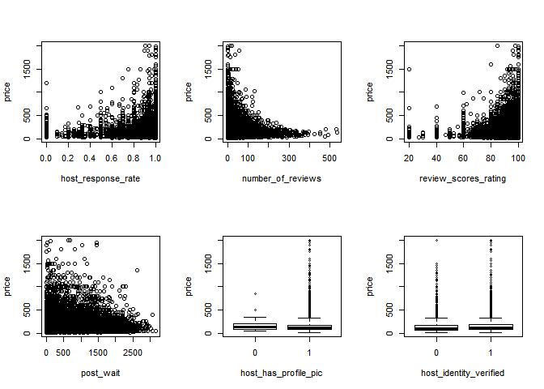

```r
# price to host and reviews
par(mfrow = c(2, 3))
for (i in 3:8){
  plot(hore.data[,1] ~ hore.data[,i],
        xlab = colnames(hore.data)[i], ylab = colnames(hore.data)[1])
}
```

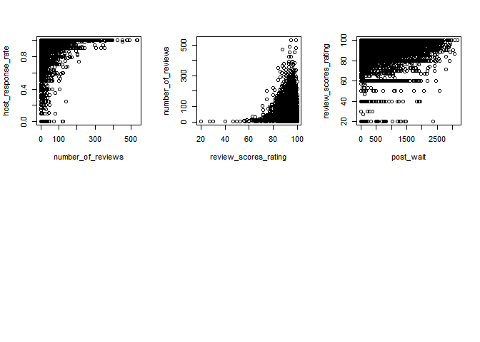

```r
par(mfrow = c(2,3))
for (i in 3:5){
  plot(hore.data[,i] ~ hore.data[,i+1],
       xlab = colnames(hore.data)[i+1], ylab = colnames(hore.data)[i])
}
```

# 3. Has Review

```r
summary(bnb.data$has_review)
```

```
##     0     1
##  7634 28109
```

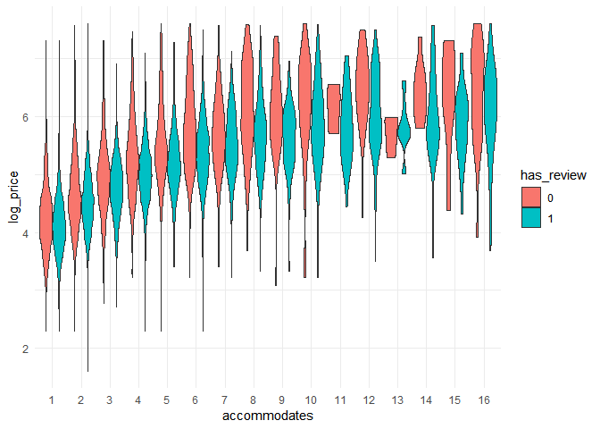

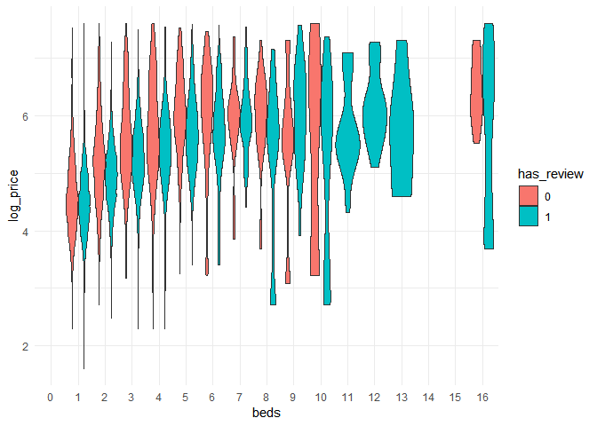

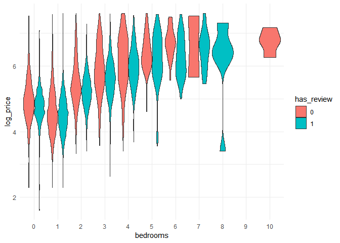

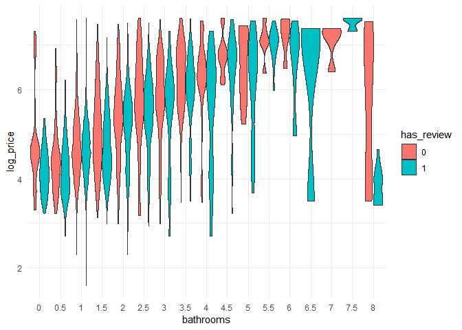

```r
for (i in 3:6){
  p <- ggplot(amen.data,
              aes(x = as.factor(amen.data[,i]), y = amen.data[,2])) +
    geom_violin(aes(x = as.factor(amen.data[,i]), y = amen.data[,2],
                    fill = has_review),
                scale = "width") +
    xlab(colnames(amen.data)[i]) +
    ylab(colnames(amen.data)[2]) +
    theme_minimal()

  print(p)
}
```

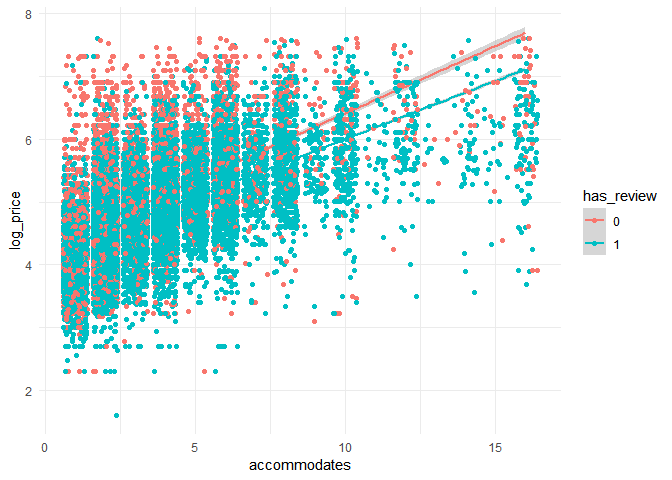

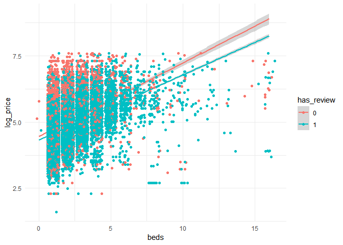

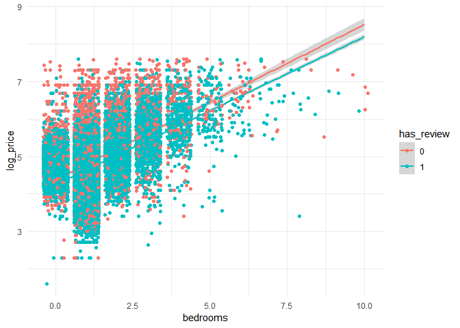

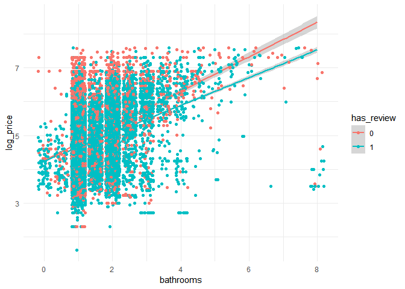

```r
for (i in 3:6){
  p <- ggplot(amen.data,
              aes(x = amen.data[,i], y = amen.data[,2], color = has_review)) +
    geom_smooth(method = lm) +
    geom_jitter() +
    xlab(colnames(amen.data)[i]) +
    ylab(colnames(amen.data)[2]) +
    theme_minimal()

  print(p)
}
```

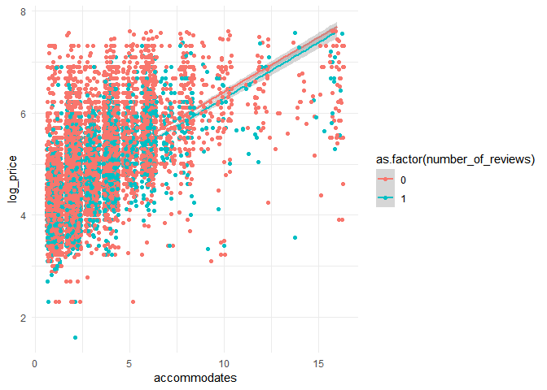

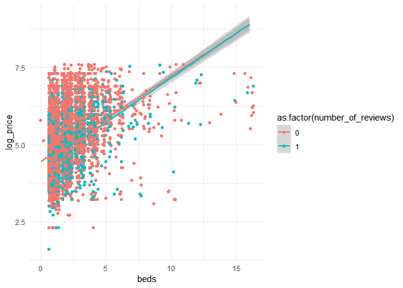

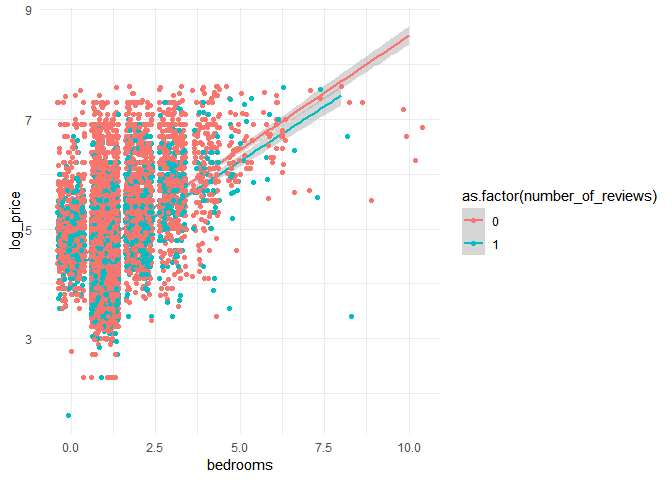

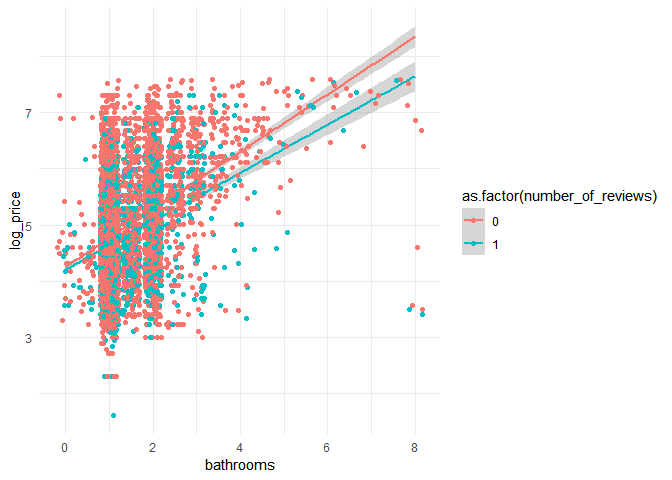

```r
# Do the same comparision between review = 0 and review = 1
# this step is no more than extra
zero.data <- filter(amen.data, (number_of_reviews == 0 | number_of_reviews == 1))

for (i in 3:6){
  p <- ggplot(zero.data,
              aes(x = zero.data[,i], y = zero.data[,2],
                  color = as.factor(number_of_reviews))) +
    geom_smooth(method = lm) +
    geom_jitter() +
    xlab(colnames(zero.data)[i]) +
    ylab(colnames(zero.data)[2]) +
    theme_minimal()

  print(p)
}
```

# 4. Do something extra

Our prior insights suggests that review_rate should have some relationship, which was not obvious in the scatter plot. So let do some transformation.

Assume price and bedrooms have linear relationship. Plot (log_)price_per_bdrm on rate. This graph, of cource, only apply to those obs with at least one review, and at least one bdrm.

The result suggests that this section is totally redundant.

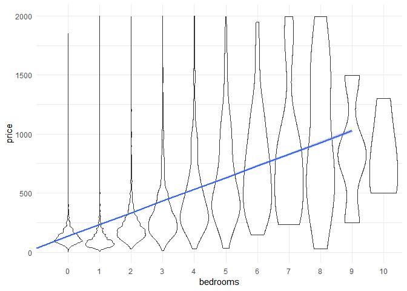

```r
# recall the graph in section 1 to see "linear" relationship of price and bdrm
i <- 5
ggplot(amen.data,aes(x = as.factor(amen.data[,i]), y = amen.data[,1])) +
    geom_violin(scale = "width") +
    geom_smooth(aes(x = amen.data[,i], y = amen.data[,1]),method = "lm") +
    xlab(colnames(amen.data)[i]) +
    ylab(colnames(amen.data)[1]) +
    theme_minimal()
```

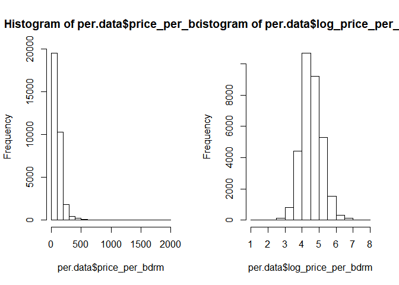

```r
per.data <- bnb.data %>%
  select(price, bedrooms, review_scores_rating) %>%
  filter(is.na(review_scores_rating)==FALSE & bedrooms>0) %>%
  mutate(price_per_bdrm = price/bedrooms,
         log_price_per_bdrm = log(price_per_bdrm))

# Ideally the distribution of price_per_bdrm should be really tight
par(mfrow = c(1, 2))
hist(per.data$price_per_bdrm)
hist(per.data$log_price_per_bdrm)
```

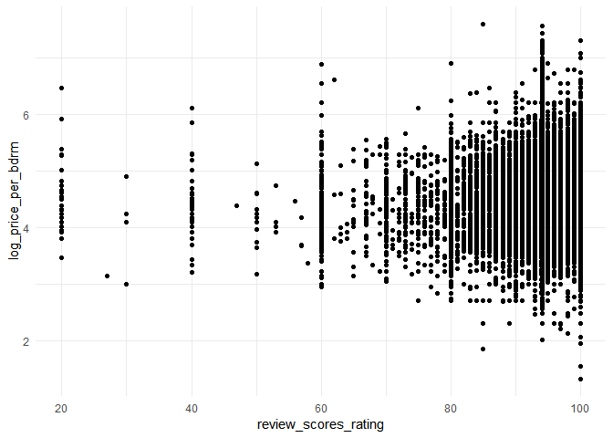

```r
# do the graph
ggplot(per.data,aes(x = review_scores_rating, y = log_price_per_bdrm)) +
  geom_point() +
    theme_minimal()
```

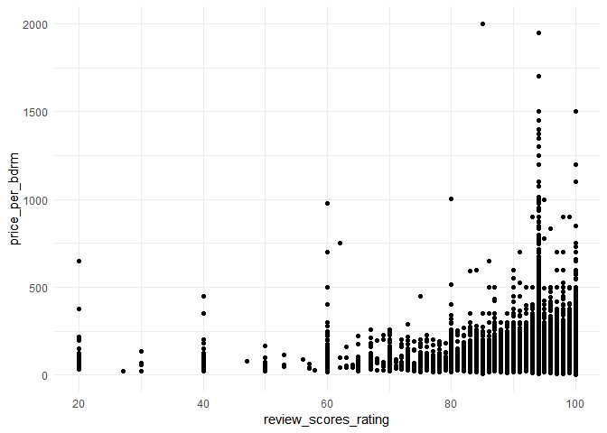

```r
ggplot(per.data,aes(x = review_scores_rating, y = price_per_bdrm)) +
  geom_point() +
    theme_minimal()
```